# Final Project 2026 — Yacht Hydrodynamic Resistance

### Posterior predictive check: constant vs learned variance

To see directly which error model covers the data better, we overlay the **posterior predictive** 95% bands of the two nonlinear models — constant variance ($\delta=0$) and learned variance ($\delta$ free) — on the observed points. Each predictive draw combines uncertainty in the mean curve with one fresh observation-level Gamma error matched to mean $\mu_i$ and standard deviation $\sigma_i$, where $\sigma_i$ is constant for the first model and mean-dependent ($\sigma_i=\sigma_0\mu_i^{\delta}$) for the second. The mean structure is identical; hull form is held at the representative beam-draught median.

```r
set.seed(7)
## Posterior predictive bands for the nonlinear mean under either variance model.
## It reads the 'delta' column, so the SAME function serves the learned-variance
## fit (delta free) and the constant-variance fit (delta = 0 => sigma_i = sigma0).
predict_nonlinear <- function(fit, X_new, n_draws = 5000) {
  d <- as.matrix(fit)
  d <- d[sample(nrow(d), n_draws), ]
  theta <- d[, paste0("theta[", seq_len(ncol(X_new)), "]"), drop = FALSE]
  eta   <- theta %*% t(X_new)
  mu    <- exp(eta)
  sigma <- d[, "sigma0"] * exp(d[, "delta"] * eta)
  yrep  <- matrix(rgamma(length(mu), shape = (mu / sigma)^2, rate = mu / (sigma * sigma)),
                  nrow = n_draws)
  list(mean  = colMeans(mu),
       lower = apply(yrep, 2, quantile, 0.025),
       upper = apply(yrep, 2, quantile, 0.975))
}

## Froude grid, hull fixed at the representative beam_draught (sample median)
fr_grid <- seq(min(yh$Froude), max(yh$Froude), length.out = 160)
bd_ref  <- median(yh$beam_draught)
Xgrid   <- cbind(intercept = 1, log_Fr = log(fr_grid) - mF, beam_draught = bd_ref - mB)

pp_homo <- predict_nonlinear(fit_M1_homo, Xgrid)   # constant variance (delta = 0)
pp_het  <- predict_nonlinear(fit_M1,      Xgrid)   # learned variance  (delta free)

## 95% predictive coverage and average band width at the observed design points
cover <- function(fit) {
  pp <- predict_nonlinear(fit, X1, n_draws = 3000)
  c(coverage = mean(y_res >= pp$lower & y_res <= pp$upper),
    mean_band_width = mean(pp$upper - pp$lower))
}
round(rbind(`M1 constant variance (delta = 0)`  = cover(fit_M1_homo),
            `M1 learned variance  (delta free)` = cover(fit_M1)), 3)
```

```
##                                   coverage mean_band_width
## M1 constant variance (delta = 0)     0.675           4.211
## M1 learned variance  (delta free)    0.929           5.414
```

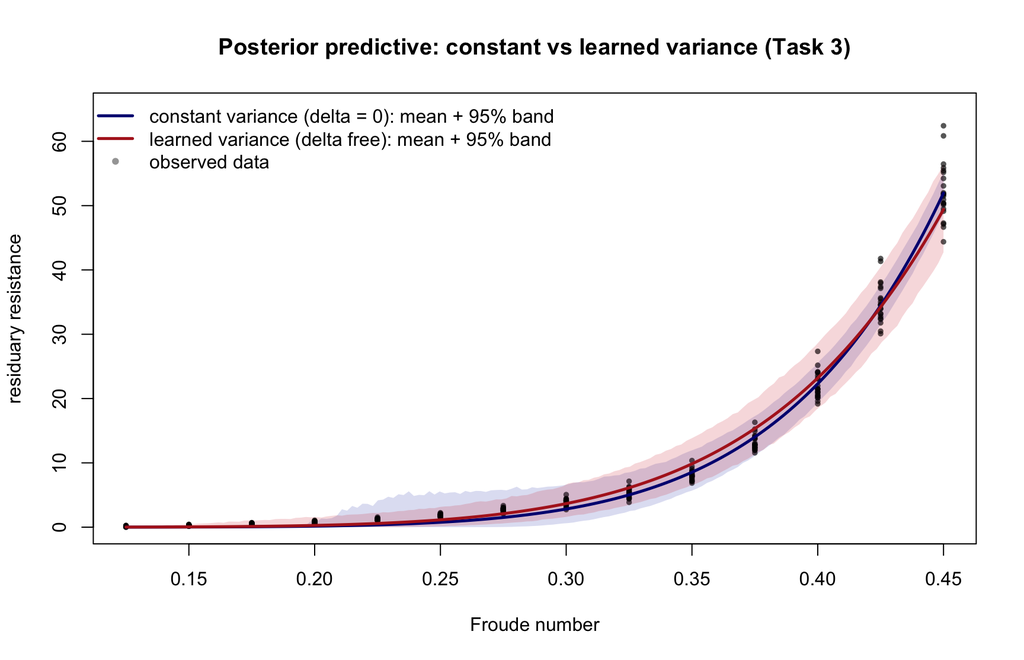

```r
ylim_top <- max(yh$resistance, pp_homo$upper, pp_het$upper)
plot(yh$Froude, yh$resistance, pch = 16, cex = 0.65, col = rgb(0, 0, 0, 0.42),
     xlab = "Froude number", ylab = "residuary resistance",
     ylim = c(0, ylim_top * 1.04),
     main = "Posterior predictive: constant vs learned variance (Task 3)")
col_homo <- rgb(0.1, 0.2, 0.7, 0.16)
col_het  <- rgb(0.8, 0.1, 0.1, 0.16)
polygon(c(fr_grid, rev(fr_grid)), c(pmax(pp_homo$lower, 0), rev(pp_homo$upper)),
        col = col_homo, border = NA)
polygon(c(fr_grid, rev(fr_grid)), c(pmax(pp_het$lower, 0), rev(pp_het$upper)),
        col = col_het, border = NA)
points(yh$Froude, yh$resistance, pch = 16, cex = 0.65, col = rgb(0, 0, 0, 0.42))
lines(fr_grid, pp_homo$mean, col = "navy",      lwd = 2.5)
lines(fr_grid, pp_het$mean,  col = "firebrick", lwd = 2.5)
legend("topleft", bty = "n", lwd = c(2.5, 2.5, NA), pch = c(NA, NA, 16),
       pt.cex = c(NA, NA, 0.8),
       col = c("navy", "firebrick", rgb(0, 0, 0, 0.42)),
       legend = c("constant variance (delta = 0): mean + 95% band",
                  "learned variance (delta free): mean + 95% band",
                  "observed data"))
```

```r
save_current_pdf("task3-ppc-var.pdf", width = 9, height = 5.8)
```

The plot shows why learning the variance matters for prediction. The constant-variance model has a band of roughly **fixed absolute width**: it is far too wide at low Froude, where the data lie in a tight sliver near zero, yet comparatively too narrow at high Froude, where the scatter is largest. The learned-variance band instead **narrows toward low Froude and widens with the resistance**, hugging the data cloud across the whole range. The coverage table quantifies the difference: the learned-variance model keeps close to nominal 95% coverage with a band that is targeted to where the data are genuinely spread out, instead of inflating the uncertainty uniformly — the predictive-side confirmation of the WAIC/PSIS-LOO verdict and the residual diagnostics.